# State MSM Profile: **Virginia**

### Background & Methods

In 2015-2016, researchers at Emory University partnered with colleagues at the Centers for Disease Control and Prevention (CDC) to develop methods to estimate the number of men who have sex with men (MSM) residing in each county in the United States. Using population and housing data from the [American Community Survey](https://www.census.gov/programs-surveys/acs/) and estimates from two peer-reviewed publications ([Oster et al., 2015](http://www.ncbi.nlm.nih.gov/pubmed/26115985) & [Purcell et al., 2012](http://www.ncbi.nlm.nih.gov/pubmed/23049658)), they derived an indirect estimate of MSM population sizes that took into account both the urbanicity of the county as well as its density of households with a male householder and a male same-sex partner.

The full methodology is published in the *Journal of Medical Internet Research - Public Health and Surveillance*:

> [Grey JA, Bernstein KT, Sullivan PS, Purcell DW, Chesson HW, Gift TL, Rosenberg ES. Estimating the population sizes of men who have sex with men in US states and counties using data from the American Community Survey. JMIR Public Health Surveill 2016;2(1):e14. DOI: 10.2196/publichealth.5365](http://publichealth.jmir.org/2016/1/e14/)

### Overview of MSM in Virginia

An estimated **112,785** men who have sex with men (MSM) resided in Virginia in 2013, representing 2.5% of the 4,503,084 MSM in the United States. Of the 3,030,663 adult men of Virginia, 3.7% had had sex with another man in the past 5 years, which was less than the overall percentage of adult men in the United States who were MSM (3.9%).

Most MSM in Virginia resided in fringe counties of large metropolitan areas (50.1%). Including both central and fringe counties, 83.1% resided in a large metropolitan area.

##### **Percentage of MSM by urbanicity, United States and Virginia, 2013**

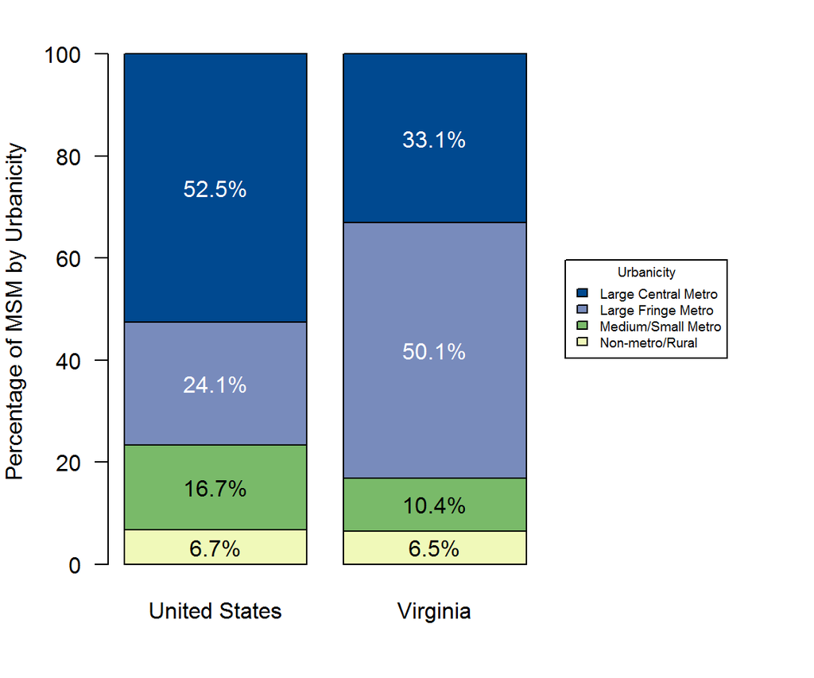

### MSM in Virginia Counties

Among counties or county-equivalent areas in Virginia, Fairfax County had the largest population of MSM at 17,454, representing 15.5% of all MSM in the state. Arlington County had the highest percentage of MSM among adult men in Virginia at 11.5%. This was greater than the percentage for Virginia as a whole, which was 3.7% of adult men.

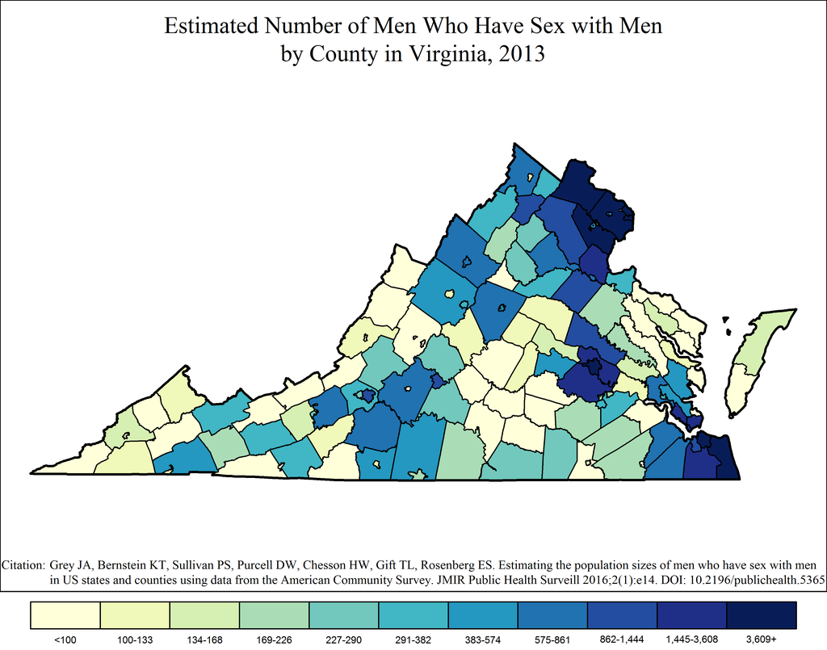

Note: Range cutpoints for the map are based on the distribution of MSM among all counties in the United States.

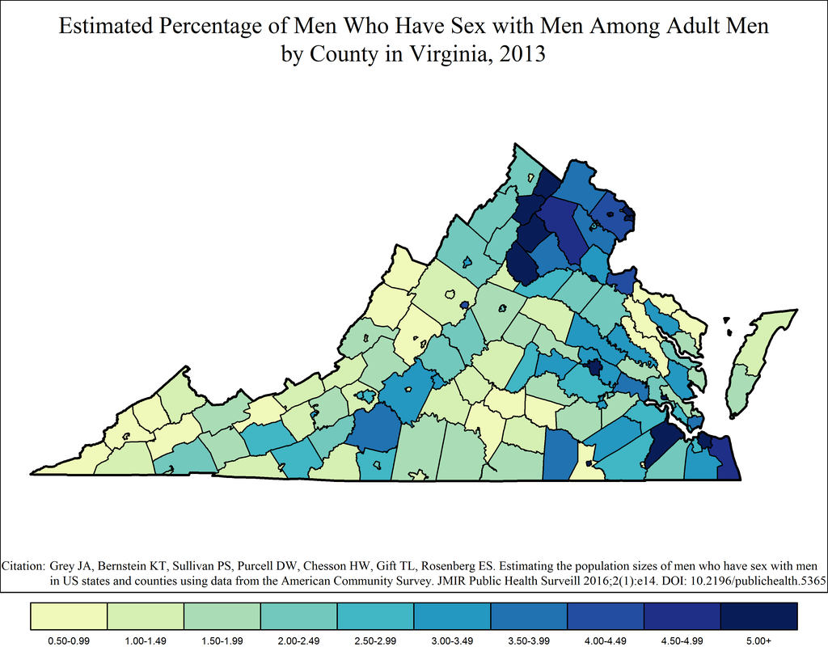

### MSM in Virginia Metropolitan Statistical Areas

#### Washington-Arlington-Alexandria Metropolitan Statistical Area

The Washington-Arlington-Alexandria MSA overlaps three states – Maryland, Virginia and West Virginia – and the District of Columbia. The Virginia portion of the MSA had the largest metropolitan population of MSM in Virginia at 51,875, or 46.0% of all MSM in the state and 42.2% of the 122,895 MSM in the MSA. Of the 1,010,882 adult men in the Virginia part of Washington-Arlington-Alexandria, an estimated 5.1% were MSM. This was less than the percentage of MSM among adult men in the MSA as a whole, which was 5.8% of adult men (122,895 out of 2,113,258).

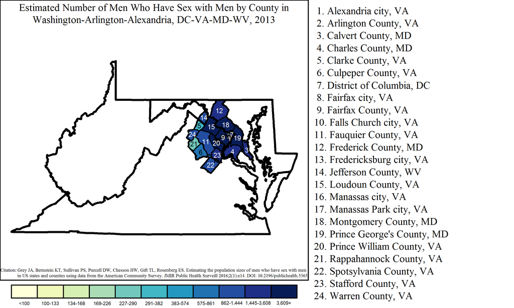

Note: Range cutpoints for the map are based on the distribution of MSM among all counties in the United States.

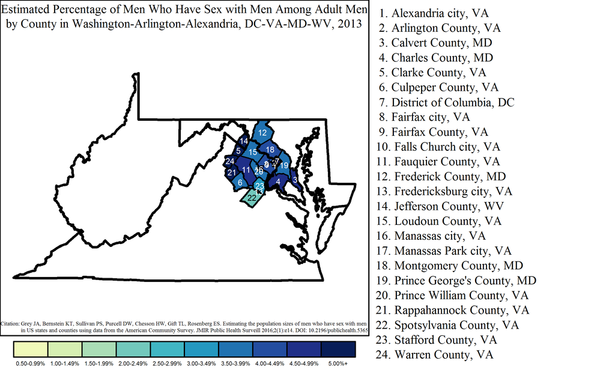

#### Virginia Beach-Norfolk-Newport News Metropolitan Statistical Area

The Virginia Beach-Norfolk-Newport News MSA overlaps two states: North Carolina and Virginia. The Virginia portion of the MSA had 24,419 MSM, or 21.7% of all MSM in the state and 98.2% of the 24,875 MSM in the MSA. Of 615,875 adult men in the Virginia part of Virginia Beach-Norfolk-Newport News, 4.0% were MSM. This was equal to the overall percentage of MSM among adult men in the MSA, which was 4.0% of adult men (24,875 out of 629,402).

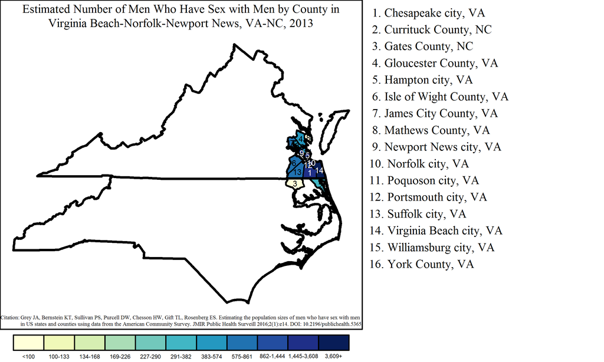

Note: Range cutpoints for the map are based on the distribution of MSM among all counties in the United States.

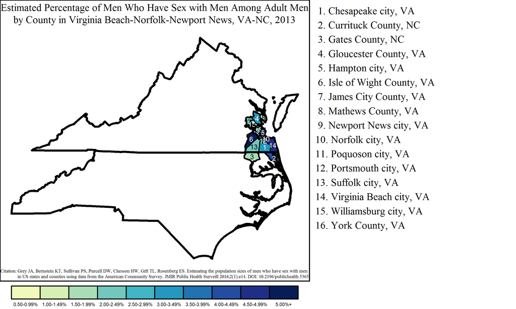

#### Richmond Metropolitan Statistical Area

The Richmond MSA had a population of 17,476 MSM, or 15.5% of all MSM in Virginia. Of the 447,574 adult men in Richmond, an estimated 3.9% were MSM.

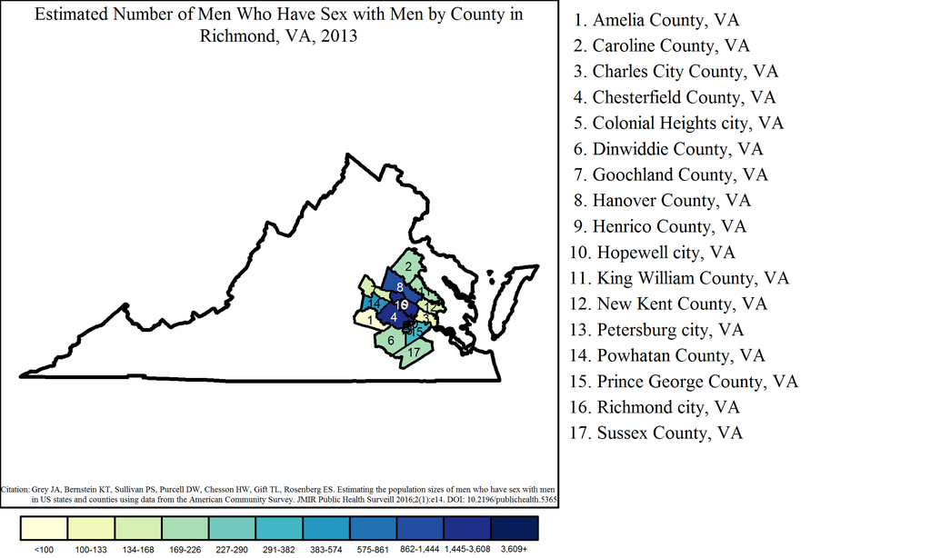

Note: Range cutpoints for the map are based on the distribution of MSM among all counties in the United States.

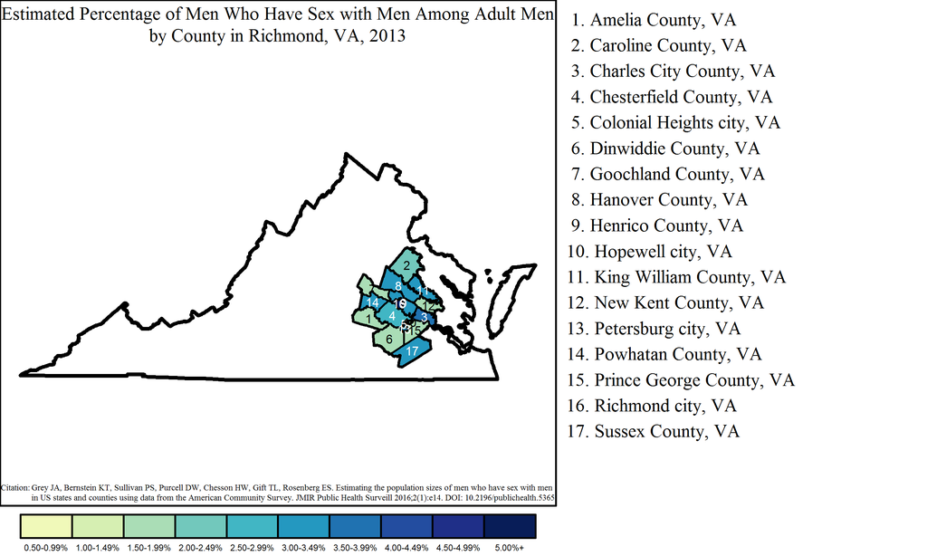

#### Roanoke Metropolitan Statistical Area

The Roanoke MSA had a population of 2,783 MSM, or 2.5% of all MSM in Virginia. Of the 115,494 adult men in Roanoke, an estimated 2.4% were MSM.

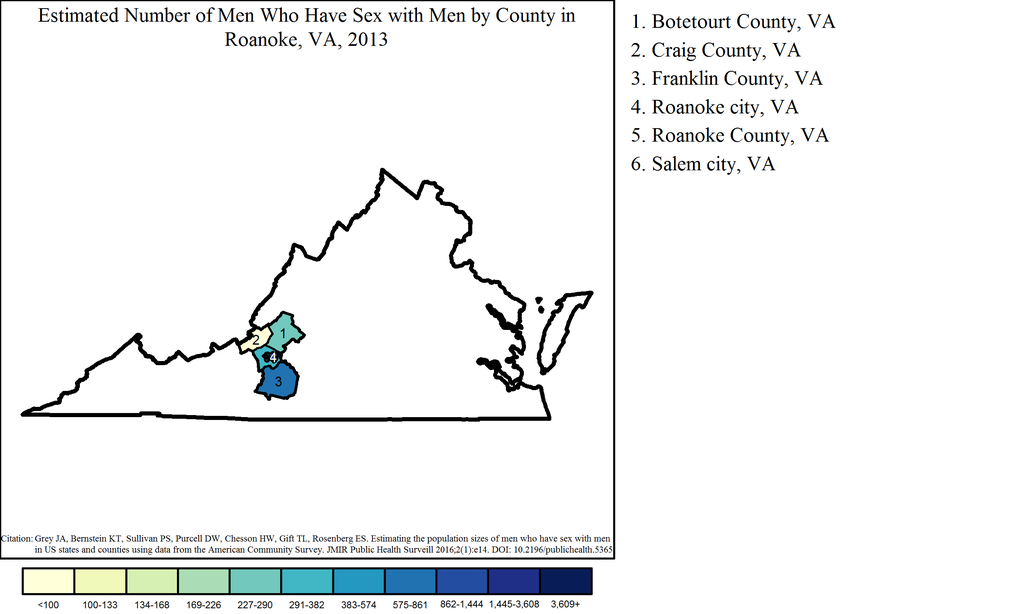

Note: Range cutpoints for the map are based on the distribution of MSM among all counties in the United States.

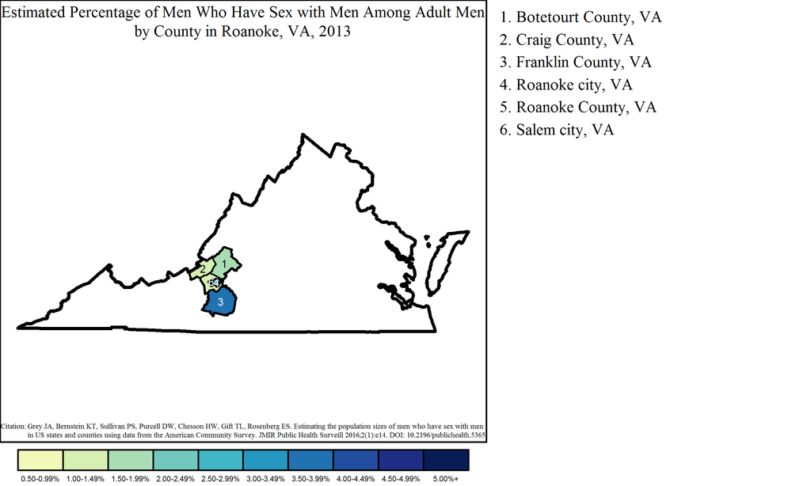

#### Lynchburg Metropolitan Statistical Area

The Lynchburg MSA had a population of 2,374 MSM, or 2.1% of all MSM in Virginia. Of the 95,220 adult men in Lynchburg, an estimated 2.5% were MSM.

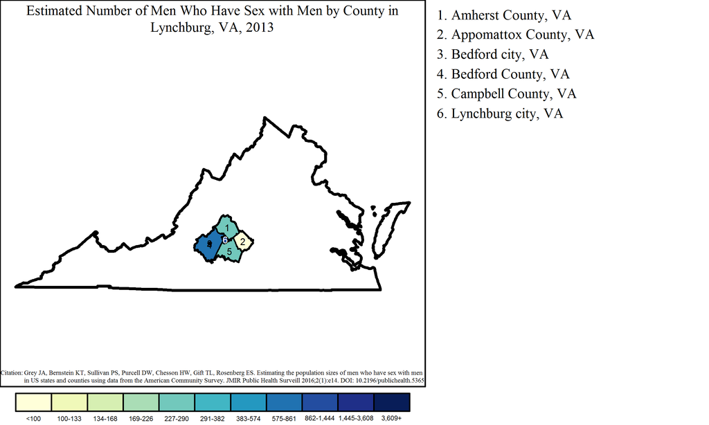

Note: Range cutpoints for the map are based on the distribution of MSM among all counties in the United States.

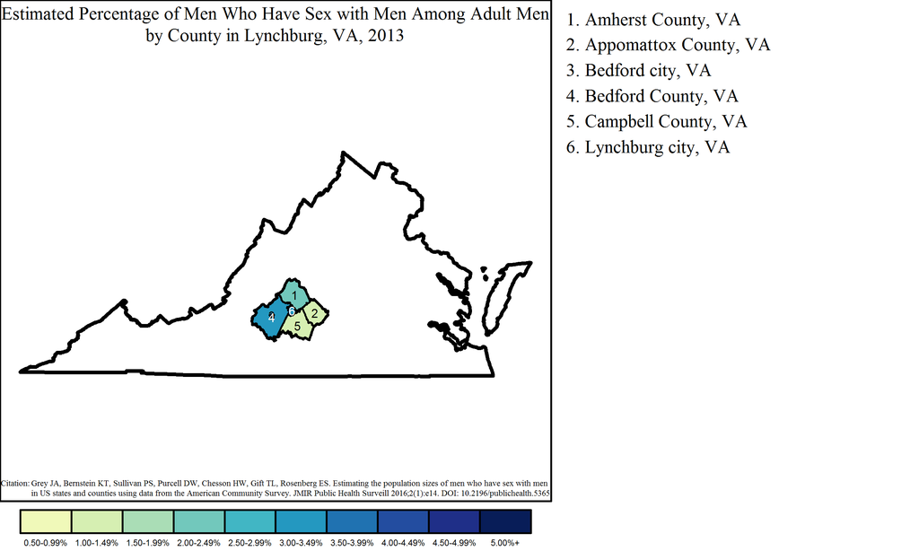

#### Charlottesville Metropolitan Statistical Area

The Charlottesville MSA had a population of 1,488 MSM, or 1.3% of all MSM in Virginia. Of the 84,142 adult men in Charlottesville, an estimated 1.8% were MSM.

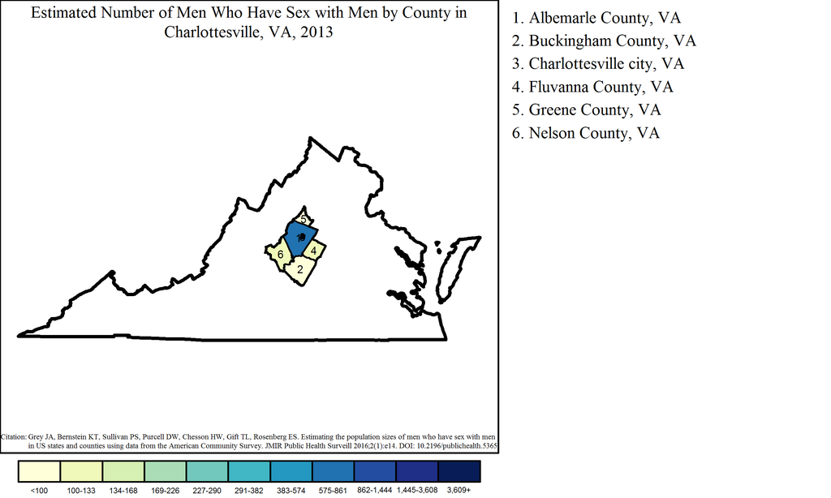

Note: Range cutpoints for the map are based on the distribution of MSM among all counties in the United States.

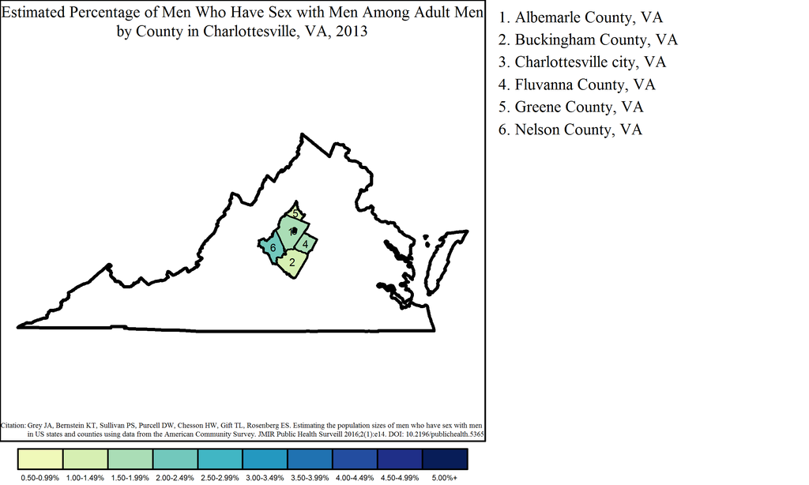

#### Blacksburg-Christiansburg-Radford Metropolitan Statistical Area

The Blacksburg-Christiansburg-Radford MSA had a population of 1,379 MSM, or 1.2% of all MSM in Virginia. Of the 74,551 adult men in Blacksburg-Christiansburg-Radford, an estimated 1.8% were MSM.

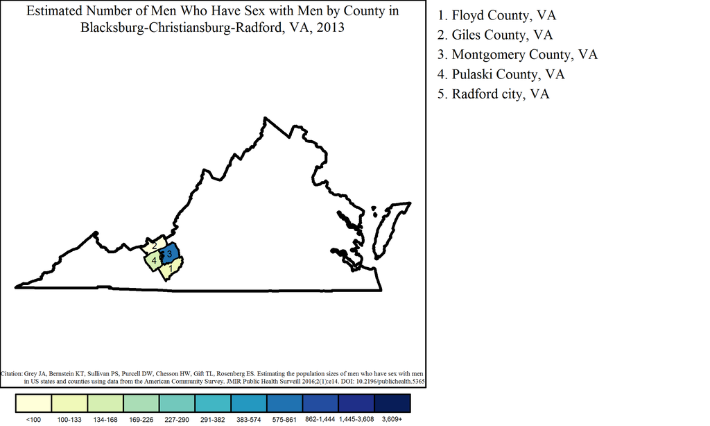

Note: Range cutpoints for the map are based on the distribution of MSM among all counties in the United States.

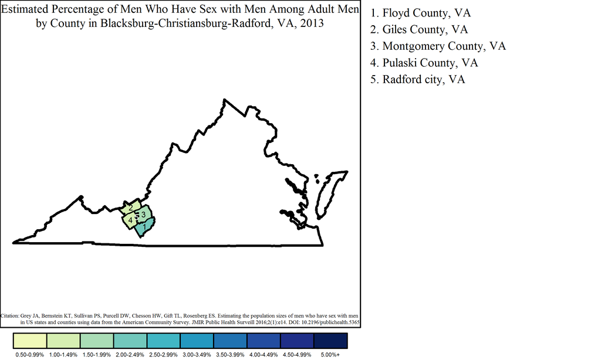

#### Harrisonburg Metropolitan Statistical Area

The Harrisonburg MSA had a population of 1,358 MSM, or 1.2% of all MSM in Virginia. Of the 48,043 adult men in Harrisonburg, an estimated 2.8% were MSM.

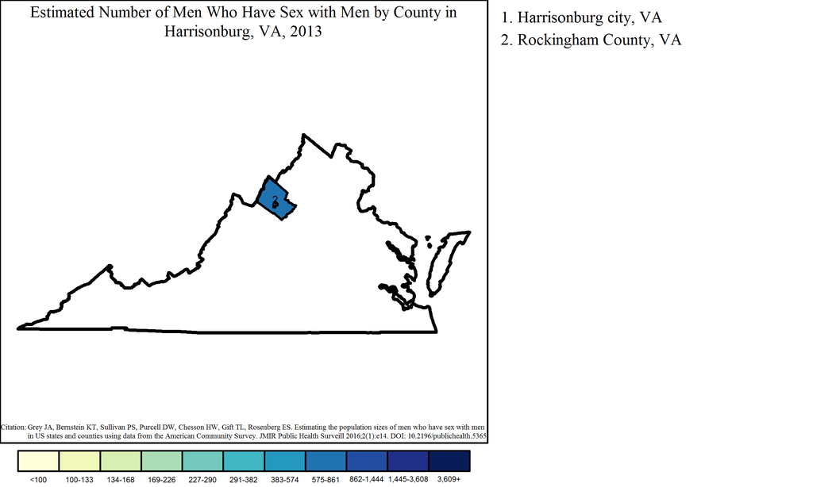

Note: Range cutpoints for the map are based on the distribution of MSM among all counties in the United States.

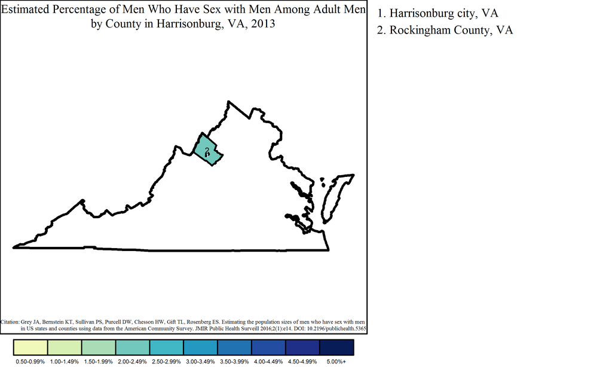

#### Staunton-Waynesboro Metropolitan Statistical Area

The Staunton-Waynesboro MSA had a population of 845 MSM, or 0.7% of all MSM in Virginia. Of the 45,621 adult men in Staunton-Waynesboro, an estimated 1.9% were MSM.

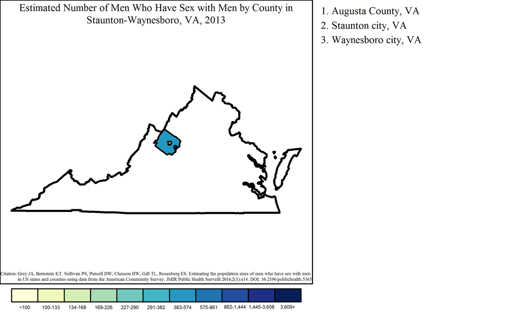

Note: Range cutpoints for the map are based on the distribution of MSM among all counties in the United States.

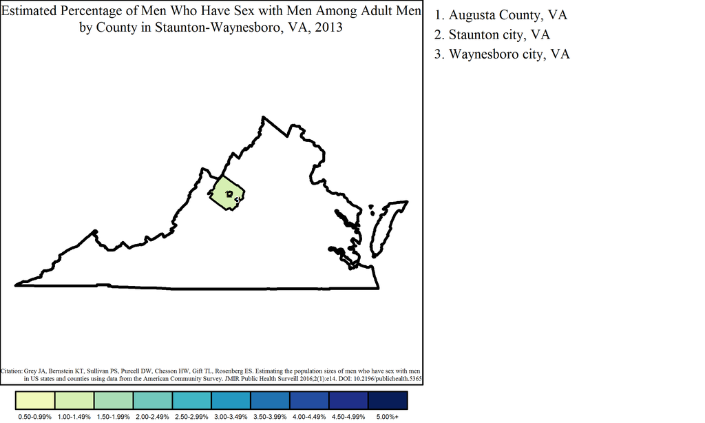

#### Winchester Metropolitan Statistical Area

The Winchester MSA overlaps two states: Virginia and West Virginia. The Virginia portion of the MSA had 732 MSM, or 0.6% of all MSM in the state and 81.7% of the 896 MSM in the MSA. Of 39,361 adult men in the Virginia part of Winchester, 1.9% were MSM. This was greater than the overall percentage of MSM among adult men in the MSA, which was 1.8% of adult men (896 out of 48,866).

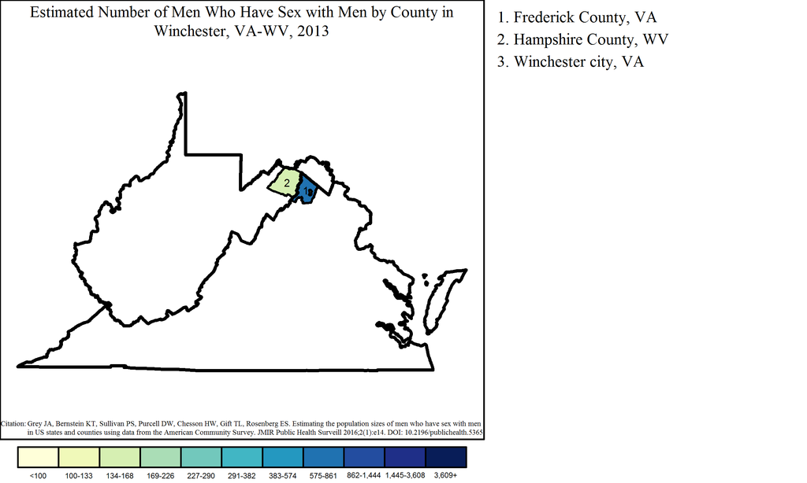

Note: Range cutpoints for the map are based on the distribution of MSM among all counties in the United States.

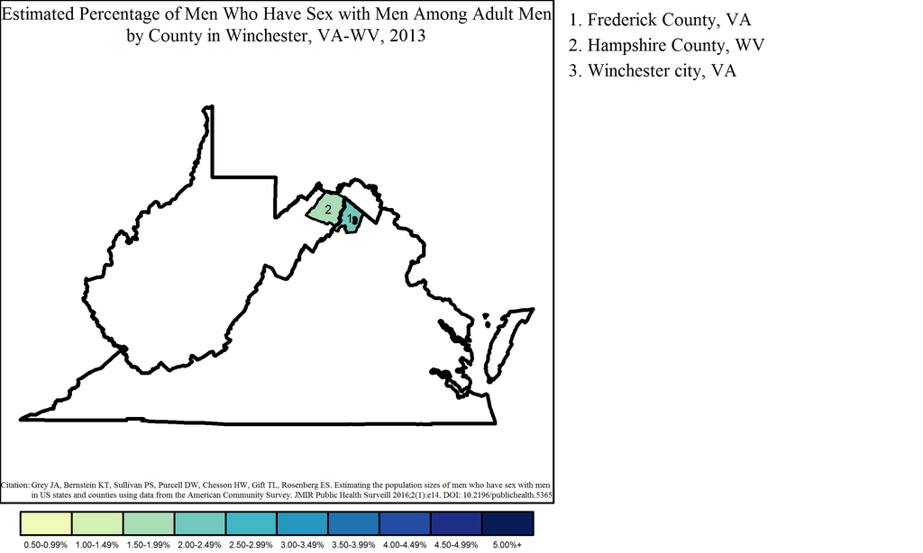

#### Kingsport-Bristol-Bristol Metropolitan Statistical Area

The Kingsport-Bristol-Bristol MSA overlaps two states: Tennessee and Virginia. The Virginia portion of the MSA had 719 MSM, or 0.6% of all MSM in the state and 35.1% of the 2,046 MSM in the MSA. Of 37,109 adult men in the Virginia part of Kingsport-Bristol-Bristol, 1.9% were MSM. This was greater than the overall percentage of MSM among adult men in the MSA, which was 1.7% of adult men (2,046 out of 118,032).

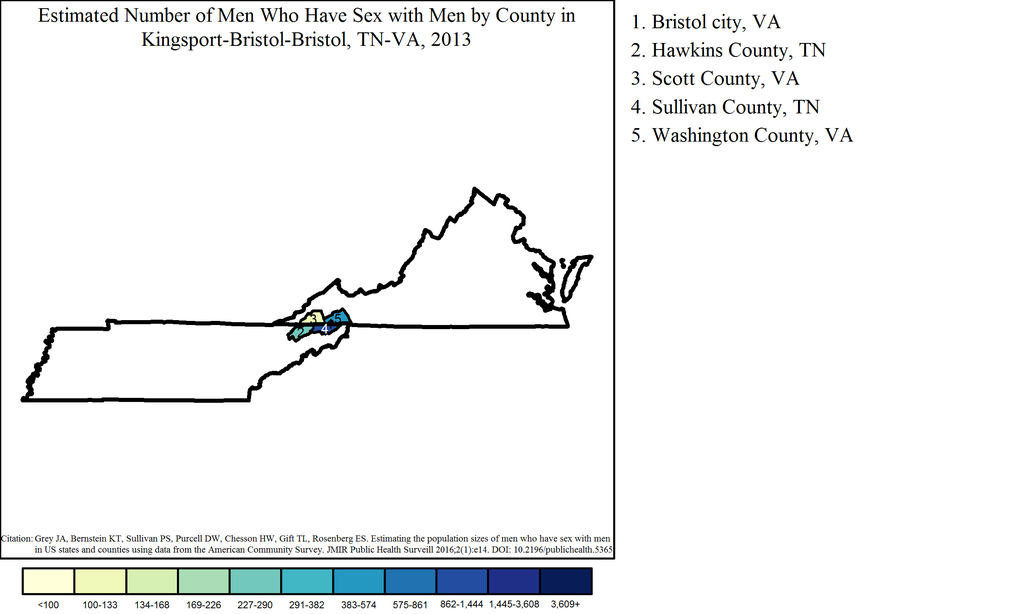

Note: Range cutpoints for the map are based on the distribution of MSM among all counties in the United States.

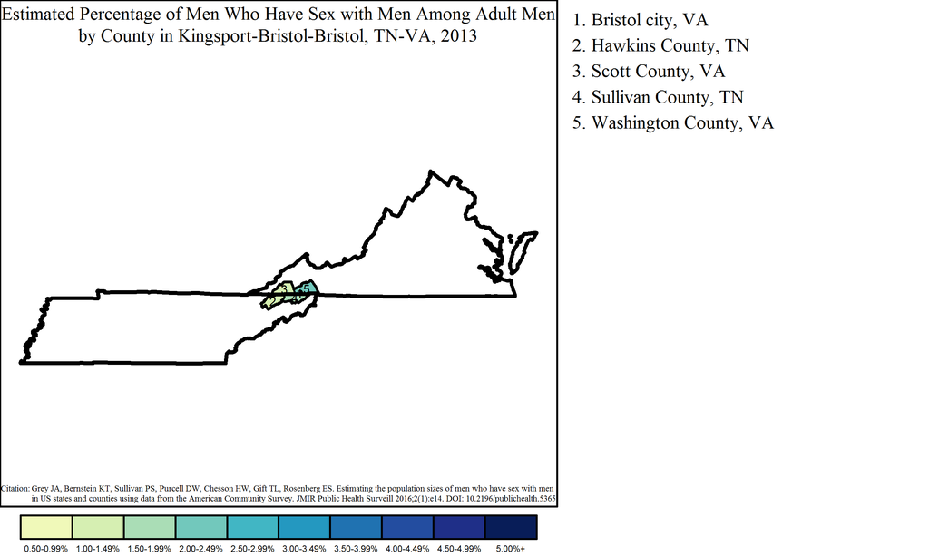